# Predicting Violent Incidents in New Orleans: An Analysis of Calls for Service Data

c-burruss

March 14, 2025

# 1. Introduction and Overview

## 1.1 Executive Summary

This analysis explores the relationship between various urban disorder indicators and violent incidents in New Orleans neighborhoods. By examining data from the city’s calls for service (CFS) system alongside other civic datasets, we investigate whether factors such as code violations, streetlight outages, abandoned vehicles, and lot abatements can serve as predictors of violent incidents. The project applies statistical analysis and machine learning techniques to identify spatial patterns, assess correlations, and develop predictive models.

Key findings reveal strong correlations between urban disorder indicators (particularly code violations and streetlight outages) and violent incidents. Our random forest model achieved the best predictive performance with an R² of 0.76, suggesting non-linear relationships between predictors and violent incidents. This understanding can assist city planners, law enforcement, and community organizations in prioritizing resources and interventions to improve public safety.

## 1.2 Dataset Description

The analysis utilizes several datasets from the City of New Orleans open data portal:

1. **Calls for Service (2023)**: Police response data including incident type, location, and time. This dataset contains 325091 records with key variables including incident type, timestamp, and geocoded location.
2. **Code Violations**: Records of property maintenance and zoning violations. This dataset provides information on 240283 code enforcement cases.
3. **311 Calls**: Citizen reports of issues including streetlight outages and abandoned vehicles. The dataset contains 887148 service requests.
4. **Chapter 66 Lot Abatements**: Records of city-initiated lot clean-ups for properties in violation. This dataset tracks 20775 abatement cases.
5. **Neighborhood Statistical Areas**: Geographic boundaries defining New Orleans neighborhoods, providing spatial context for our analysis.

These datasets were selected based on theoretical frameworks suggesting relationships between urban disorder and crime, particularly the “broken windows” theory proposed by Kelling and Wilson (1982).

## 1.3 Project Goals

The primary objectives of this analysis are to: 1. Identify spatial patterns of violent incidents across New Orleans neighborhoods. 2. Assess correlations between urban disorder indicators and violent incidents. 3. Develop predictive models to determine which factors best predict neighborhood violence. 4. Provide data-driven insights to inform community safety initiatives.

To achieve these goals, we employ a combination of geospatial analysis, statistical correlation tests, and machine learning models. We compare the performance of multiple modeling approaches, including linear regression, random forest, elastic net regression, and multivariate adaptive regression splines (MARS), to identify the most effective predictive framework.

# 2. Methods and Analysis

## 2.1 Data Preparation

In this section, we prepare the environment, define helper functions, and acquire the necessary datasets. We use a combination of R packages for spatial analysis (`sf`, `spdep`), data wrangling (`tidyverse`), and machine learning (`tidymodels`). The `pasteurize` function standardizes data cleaning operations for our calls for service dataset, ensuring consistency in column naming and formatting.

### 2.1.1 Setting Up the Environment

### 2.1.2 Helper Functions

### 2.1.3 Data Acquisition

```r
# Download neighborhoods spatial file
path <- './data/neighborhoods.geojson'
github_url <- 'https://raw.githubusercontent.com/CBurruss/HarvardX-CYO/main/data/neighborhoods.geojson'
if (!file.exists(path)) {
  download.file(github_url, path, mode = 'wb') # 'wb' ensures binary mode for non-text files
} else {
  message('The neighborhoods file exists!')
}

# Download 2023 calls for service (cfs)
path <- './data/cfs-2023.csv'
if(!file.exists(path)) {
  # Download data and save it to file
  cfs_file <- read.socrata('https://data.nola.gov/api/odata/v4/pc5d-tvaw')
  write.csv(cfs_file, file = path, row.names = FALSE)
  message('The cfs file has been downloaded and saved to ', path)
} else {
  message('The cfs file already exists at ', path, '!')
}

# Download code violations
path <- './data/violations.csv'
if(!file.exists(path)) {
  # Download data and save it to file
  violations_file <- read.socrata('https://data.nola.gov/api/odata/v4/3ehi-je3s')
  write.csv(violations_file, file = path, row.names = FALSE)
  message('The violations file has been downloaded and saved to ', path)
} else {
  message('The violations file already exists at ', path, '!')
}

# Download 311 calls (for streetlight outages and abandoned vehicles)
path <- './data/311.csv'
if(!file.exists(path)) {
  # Download data and save it to file
  three11_file <- read.socrata('https://data.nola.gov/api/odata/v4/2jgv-pqrq')
  write.csv(three11_file, file = path, row.names = FALSE)
  message('The 311 file has been downloaded and saved to ', path)
} else {
  message('The 311 file already exists at ', path, '!')
}

rm(three11_file)

# Download ch 66 lot abatements
path <- './data/ch66.csv'
if(!file.exists(path)) {
  # Download data and save it to file
  ch66_file <- read.socrata('https://data.nola.gov/api/odata/v4/xhih-vxs6')
  write.csv(ch66_file, file = path, row.names = FALSE)
  message('The ch 66 file has been downloaded and saved to ', path)
} else {
  message('The ch 66 file already exists at ', path, '!')
}
```

## 2.2 Data Processing and Exploration

### 2.2.1 Processing Calls for Service Data

The calls for service data requires careful processing to extract usable geographic coordinates and convert them into a spatial format compatible with other datasets. We convert the data to a spatial feature (`sf`) object with the WGS 84 coordinate reference system (EPSG:4326) to ensure compatibility with the neighborhoods spatial file.

```
## Rows: 130,228
## Columns: 24
## $ nopd_item       <chr> "A0000323", "A0000623", "A0000723", "A0000923", "A0001…
## $ type            <chr> "Stfired", "Stfired", "Stfired", "Stfired", "Suspp", "…
## $ typetext        <chr> "Shots Fired", "Shots Fired", "Shots Fired", "Shots Fi…
## $ priority        <chr> "1", "1", "1", "1", "2", "1", "1", "1", "1", "2", "1",…
## $ initialtype     <chr> "Stfired", "Stfired", "Stfired", "Stfired", "Suspp", "…
## $ initialtypetext <chr> "Shots Fired", "Shots Fired", "Shots Fired", "Shots Fi…
## $ initialpriority <chr> "2", "2", "2", "2", "1", "2", "2", "2", "2", "2", "2",…
## $ mapx            <int> 3696157, 3698194, 3679649, 3676773, 3702360, 3681601, …
## $ mapy            <int> 532824, 533068, 533305, 536990, 520618, 552052, 534643…
## $ timecreate      <chr> "2023-01-01 00:01:27", "2023-01-01 00:03:09", "2023-01…
## $ date            <date> 2023-01-01, 2023-01-01, 2023-01-01, 2023-01-01, 2023-…
## $ year            <chr> "2023", "2023", "2023", "2023", "2023", "2023", "2023"…
## $ timedispatch    <chr> "2023-01-01 10:36:08", "2023-01-01 10:27:30", "2023-01…
## $ timearrive      <chr> "2023-01-01 10:38:51", "2023-01-01 10:29:39", "2023-01…
## $ timeclosed      <chr> "2023-01-01 10:46:04", "2023-01-01 10:35:41", "2023-01…
## $ disposition     <chr> "Goa", "Goa", "Goa", "Goa", "Goa", "Goa", "Goa", "Goa"…
## $ dispositiontext <chr> "Gone On Arrival", "Gone On Arrival", "Gone On Arrival…
## $ selfinitiated   <chr> "N", "N", "N", "N", "N", "N", "N", "N", "N", "N", "N",…
## $ beat            <chr> "5e01", "5e04", "1e01", "1i03", "4d04", "3q02", "1e03"…
## $ block_address   <chr> "007xx Blk Lizardi St", "009xx Blk Lamanche St", "N Vi…
## $ zip             <chr> "70117", "70117", "70112", "70119", "70131", "70122", …
## $ policedistrict  <int> 5, 5, 1, 1, 4, 3, 1, 3, 3, 5, 6, 5, 7, 3, 1, 3, 4, 6, …
## $ location        <chr> "Point (-90.02173891 29.95862992)", "Point (-90.015299…
## $ geometry        <POINT [°]> POINT (-90.02174 29.95863), POINT (-90.0153 29.9…
```

### 2.2.2 Identifying Violent Incidents

To classify violent incidents, we developed a keyword-based approach that identifies calls related to violent crimes. This approach was chosen over using official crime classification codes because it allows us to capture a broader range of incidents that may involve violence or threats of violence. We include keywords such as “assault,” “shooting,” and “homicide,” while excluding false positives with exclusion terms like “alarm” and “not occupied.”

Top 15 Violent Incident Types in New Orleans (2023)

| typetext | count | percent |
| --- | --- | --- |
| Domestic Dispute | 7465 | 35% |
| Domestic Violence | 3895 | 18% |
| Burglary From Vehicle | 3058 | 14% |
| Simple Assault | 2809 | 13% |
| Assault W/weapon (pd) | 1023 | 5% |
| Fight | 959 | 4% |
| Commercial Burglary | 707 | 3% |
| Robbery W/weapon | 330 | 2% |
| Robbery | 308 | 1% |
| Assault W/weapon - Shooting (pd) | 231 | 1% |
| Shooting (pd) | 197 | 1% |
| Carjacking: Robbery | 134 | 1% |
| Reclass: Murder By Shoooting | 134 | 1% |
| Stabbing (pd) | 96 | 0% |
| Assault W/weapon - Stabbing (pd) | 89 | 0% |

### 2.2.3 Processing Neighborhood Data

The neighborhood spatial file undergoes a similar spatial transformation as the CFS data to ensure they can both be mapped with identical scaling parameters.

### 2.2.4 Visualizing Neighborhoods and Violent Incidents

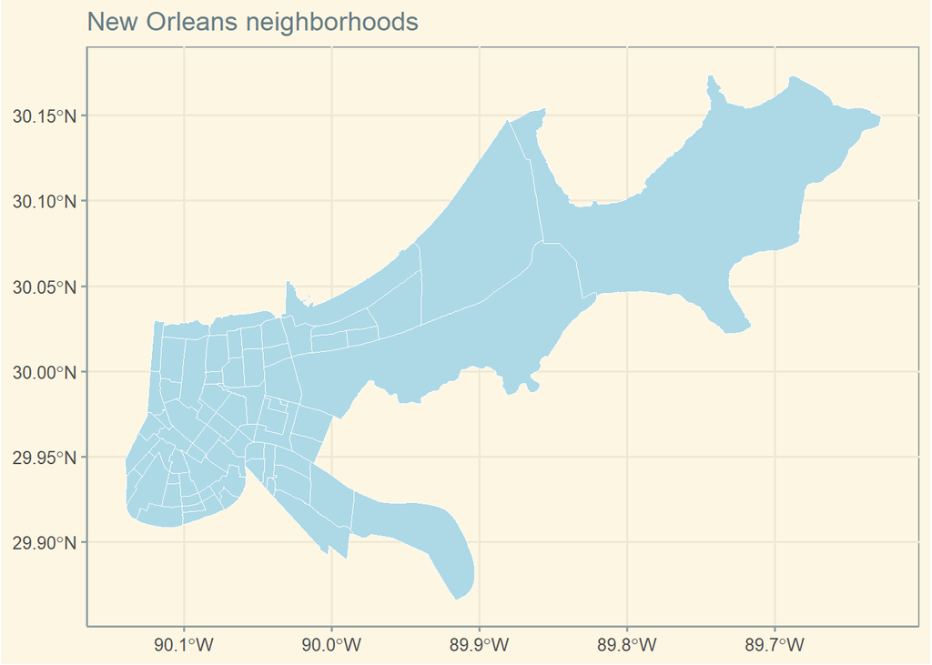

New Orleans Neighborhoods

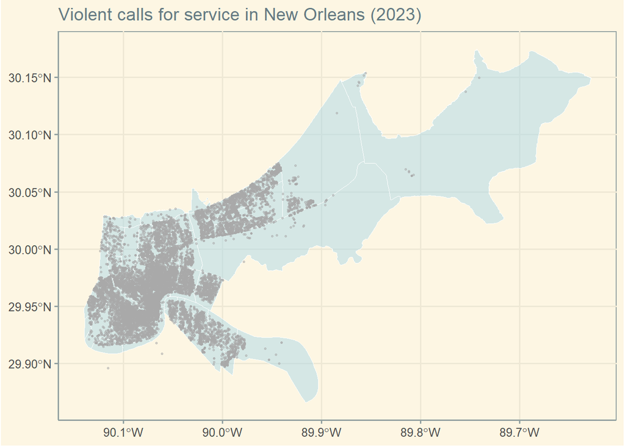

Violent Calls for Service in New Orleans (2023)

### 2.2.5 Processing Risk Factor Data

Next, the risk factors undergo a similar transformation process as the CFS dataset. The code violations in particular must be geocoded with `tidygeocoder` to map their points across the city. Invalid geometries are handled with either `na.omit()` or `st_make_valid()` to ensure each dataset can be uniformly mapped.

## 2.3 Data Aggregation by Neighborhood

Next, we aggregate each dataset at the neighborhood level by interpolating points to each neighborhood geometry. This similarly drops any values which do not map to a corresponding polygon from the neighborhood set.

## 2.4 Statistical Analysis

### 2.4.1 Correlation Analysis

We chose Pearson correlation analysis to examine relationships between urban disorder indicators and violent incidents because it provides a standardized measure of linear association between variables. While correlation does not imply causation, strong correlations suggest potential predictive relationships that can be explored further with more complex models.

Correlation of Urban Disorder Indicators with Violent Incidents

|  | factor | correlation | p_value | significance |
| --- | --- | --- | --- | --- |
| cor | code_violations | 0.7353676 | 0.0000000 | *** |
| cor1 | streetlight_outages | 0.6948072 | 0.0000000 | *** |
| cor2 | abandoned_vehicles | 0.6454900 | 0.0000000 | *** |
| cor3 | lot_abatements | 0.1609282 | 0.1768739 | ns |

### 2.4.2 Visualizing Relationships

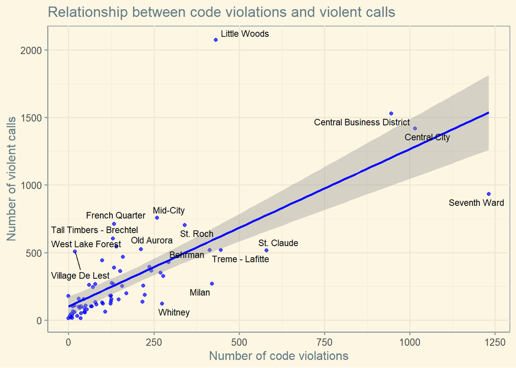

Relationship between Code Violations and Violent Calls

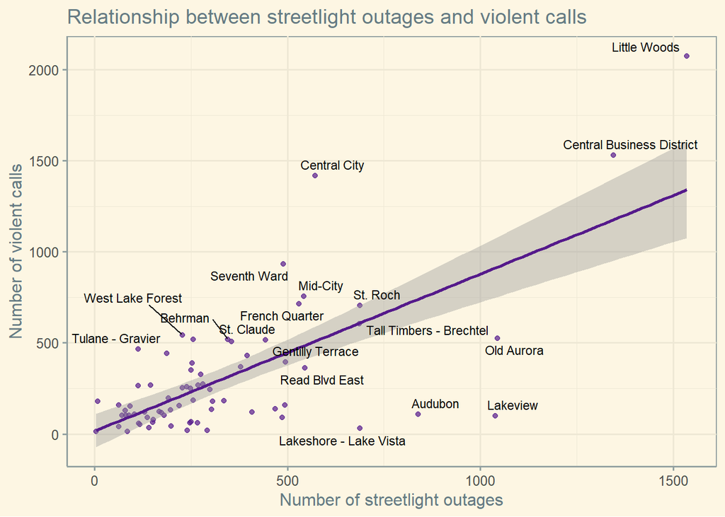

Relationship between Streetlight Outages and Violent Calls

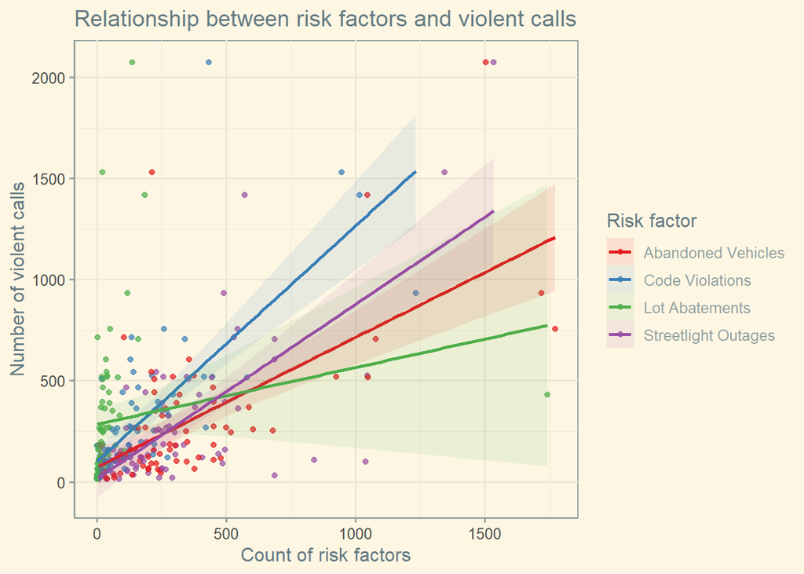

Relationship between All Risk Factors and Violent Calls

# 3. Predictive Modeling

## 3.1 Data Preparation for Modeling

We split our dataset into training (80%) and testing (20%) sets using stratified sampling. This 80/20 split represents a balance between providing sufficient data for model training while retaining enough for meaningful evaluation. We chose this split ratio based on the smaller size of our dataset and the need to ensure adequate representation of all neighborhoods in both training and testing sets.

For cross-validation, we implement 5-fold cross-validation, which lets us balance computational efficiency and performance estimation. With our limited number of neighborhoods, using more folds (e.g., 10-fold) could result in too few samples per fold, while fewer folds might not provide sufficient performance estimates.

## 3.2 Linear Regression Model

We begin with linear regression as our baseline model due to its interpretability, including the benefit of quantifying the individual contribution of each risk factor in the model. Linear regression expects a linear relationship between predictors and our outcome, which is a reasonable assumption about our data based on the initial correlation analysis.

```
## Linear Model Performance Metrics:
```

| .metric | .estimator | .estimate |
| --- | --- | --- |
| rmse | standard | 218.7524791 |
| rsq | standard | 0.6356768 |
| mae | standard | 158.7528721 |

```
##
## Model Coefficients:
```

| term | estimate | std.error | statistic | p.value |
| --- | --- | --- | --- | --- |
| (Intercept) | -64.3345282 | 39.3048892 | -1.6368073 | 0.1077095 |
| streetlight_outages | 0.5999492 | 0.0941183 | 6.3744166 | 0.0000000 |
| code_violations | 0.4960455 | 0.1492911 | 3.3226735 | 0.0016374 |
| abandoned_vehicles | 0.2159065 | 0.0845565 | 2.5534007 | 0.0136398 |
| lot_abatements | 0.0407504 | 0.1098630 | 0.3709206 | 0.7122035 |

## 3.3 Random Forest Model

We implement random forest as our first advanced model because it can capture non-linear relationships and interactions between variables without requiring explicit specification. Unlike linear regression, random forest models are resistant to overfitting, handle multicollinearity well, and provide measures of variable importance that can offer insights beyond standard regression coefficients.

For the random forest model, we tune two key hyperparameters: 1. `mtry`: The number of variables randomly sampled as candidates at each split. We test values from 1 to 4 (the total number of predictors). 2. `min_n`: The minimum number of observations needed in a node to be considered for splitting. We test values from 2 to 10.

We fix the number of trees at 1,000 to ensure model stability while maintaining computational efficiency.

```
## Random Forest Performance Metrics:
```

| .metric | .estimator | .estimate |
| --- | --- | --- |
| rmse | standard | 211.1628185 |
| rsq | standard | 0.7553407 |
| mae | standard | 132.4899630 |

```
##
## Variable Importance:
```

| Variable | Importance |
| --- | --- |
| streetlight_outages | 2029508 |
| code_violations | 1971407 |
| abandoned_vehicles | 1574213 |
| lot_abatements | 1391160 |

## 3.4 Elastic Net Regression Model

Next, we implement an elastic net regularization parameter on a regression model. This form of regression combines the penalties of both lasso and ridge regularization, making it particularly useful when dealing with potentially correlated predictors. By tuning the mixture parameter (alpha), we can determine the optimal balance between the L1 and L2 penalties. We include this model to compare with our other approaches and to potentially identify the most important predictors while controlling for multicollinearity among our risk factors.

```
## Elastic Net Model Performance Metrics:
```

| .metric | .estimator | .estimate |
| --- | --- | --- |
| rmse | standard | 220.745628 |
| rsq | standard | 0.633974 |
| mae | standard | 159.090897 |

```
##
## Elastic Net Coefficients:
```

| term | estimate | penalty |
| --- | --- | --- |
| (Intercept) | 303.964912 | 10 |
| streetlight_outages | 176.747023 | 10 |
| code_violations | 107.366205 | 10 |
| abandoned_vehicles | 77.641897 | 10 |
| lot_abatements | 0.630998 | 10 |

## 3.5 Multivariate Adaptive Regression Splines (MARS)

Lastly, we attempt a MARS model as an alternative approach to capturing non-linear relationships through piecewise linear segments (splines). This technique automatically determines the optimal locations (knots) where the relationship between predictors and the outcome changes. We include MARS to explore whether the relationship between urban disorder indicators and violent incidents contains significant non-linearities that might not be captured by our other models. This model similarly selects the best hyperparameters to minimize RMSE.

```
## MARS Performance Metrics:
```

| .metric | .estimator | .estimate |
| --- | --- | --- |
| rmse | standard | 259.2768079 |
| rsq | standard | 0.6264477 |
| mae | standard | 151.1029567 |

## 3.6 Model Comparison

Finally, we evaluate model performance using two primary metrics: 1. Root Mean Square Error (RMSE): Measures the average magnitude of prediction errors in the same units as the response variable. 2. R-squared (R²): Indicates the proportion of variance in violent incidents explained by each model.

We choose these metrics because RMSE provides a concrete measure of prediction accuracy in terms of the number of violent incidents, while R² offers insight into the explanatory power of our models relative to the overall variance in the data.

Comprehensive Model Performance Comparison

| Model | RMSE | R_squared |
| --- | --- | --- |
| Random Forest | 211.16 | 0.76 |
| Linear Regression | 218.75 | 0.64 |
| Elastic Net | 220.75 | 0.63 |
| MARS | 259.28 | 0.63 |

# 4. Results and Discussion

## 4.1 Correlation Analysis Findings

Our correlation analysis revealed strong relationships between several urban disorder indicators and violent incidents in New Orleans neighborhoods. Code violations showed the strongest correlation with violent incidents (r = 0.74, p < 0.001), followed by streetlight outages (r = 0.69, p < 0.001) and abandoned vehicles (r = 0.65, p < 0.001). Lot abatements showed a weaker and non-significant correlation (r = 0.16, p = 0.18).

These findings align with the “broken windows” theory of urban disorder, which suggests that visible signs of disorder and neglect may contribute to an environment where crime is more prevalent. The spatial visualization of violent incidents shows clustering in certain neighborhoods, which corresponds with areas that have higher concentrations of code violations and other disorder indicators.

## 4.2 Predictive Model Performance

We compared four predictive models to understand the relationships between urban disorder indicators and violent incidents: linear regression, random forest, elastic net regression, and multivariate adaptive regression splines (MARS).

### 4.2.4 Multivariate Adaptive Regression Splines (MARS)

The MARS model, which can flexibly capture non-linear relationships between predictors and the outcome, achieved an RMSE of 259.28 and an R-squared of 0.63. This performance ranked last among our models, possibly pointing to the limitations of such small universe of data. The model identified similar key predictors to the other approaches, suggesting that while there may be some non-linearity in the relationships, the overall pattern of importance among predictors remains consistent.

### 4.2.5 Model Comparison

Comparing all four models, the random forest model achieved the lowest RMSE (211.16), suggesting it provides the most accurate predictions on our test set. It was also able to account for the largest portion of variance in our data with an r-squared of 0.76 - substantially higher than our other models.The relative consistency in performance across different modeling approaches suggests that our findings regarding the importance of streetlight outages and code violations as predictors of violent incidents are robust.

## 4.3 Spatial Patterns

The spatial distribution of violent incidents across New Orleans neighborhoods also reveals distinct patterns. Certain neighborhoods consistently show higher concentrations of both violent incidents and urban disorder indicators. This spatial clustering suggests that interventions focused on specific high-risk neighborhoods might be more effective than city-wide approaches.

The neighborhoods with the highest concentrations of violent incidents also tend to have the highest numbers of streetlight outages and code violations, further supporting the correlation between these factors. This spatial coincidence of urban disorder and violence provides additional evidence for the theoretical connection between physical disorder and crime.

## 4.4 Implications of Findings

These findings have several important implications:

1. **Predictive Value of Risk Factors**: The strong and consistent relationship between streetlight outages and code violations with violent incidents across all models suggests that these may serve as valuable early indicators of neighborhood conditions conducive to violence. This provides empirical support for policy approaches that target code enforcement as part of comprehensive violence reduction strategies.
2. **Importance of Infrastructure Maintenance**: The significant relationship between streetlight outages and violent incidents highlights the importance of basic infrastructure maintenance in crime prevention. This finding aligns with situational crime prevention theory, which emphasizes how environmental conditions can influence criminal opportunities (Braga, 2024).
3. **Targeted Intervention Opportunities**: The spatial clustering of both disorder indicators and violent incidents suggests that targeted interventions in high-risk neighborhoods could be particularly effective. Resources for both environmental remediation and crime prevention might be most efficiently allocated by focusing on neighborhoods with high concentrations of streetlight outages and code violations, such as the Central Business District (CBD), Little Woods, Central City and the Seventh Ward.
4. **Integrated Approach**: The multiple predictors identified suggest that an integrated approach addressing various forms of physical disorder simultaneously might be more effective than focusing on single factors in isolation.

# 5. Conclusion

## 5.1 Summary of Findings

This analysis identified significant relationships between urban disorder indicators and violent incidents in New Orleans neighborhoods. Streetlight outages emerged as the strongest predictor of neighborhood violence, followed by code violations and abandoned vehicles. Our predictive models (namely random forests) achieved reasonable accuracy, with R-squared values up to 0.76, indicating that these disorder indicators explain a substantial portion of the variance in violent incidents across neighborhoods.

## 5.2 Implications for Policy and Practice

These findings have several implications for public safety initiatives in New Orleans:

1. **Infrastructure Maintenance**: The significant association between streetlight outages and violent incidents suggests that improving street lighting maintenance could be a relatively straightforward intervention to enhance neighborhood safety.
2. **Targeted Code Enforcement**: Given the strong relationship between code violations and violent incidents, strengthening code enforcement in high-risk neighborhoods could similarly contribute to violence reduction.
3. **Data-Driven Resource Allocation**: The spatial patterns identified in this analysis can inform more targeted allocation of public safety resources to neighborhoods with higher concentrations of risk factors.
4. **Cross-Department Collaboration**: Addressing neighborhood violence effectively may require collaboration across multiple city departments, including the public works and code enforcement departments.

## 5.3 Limitations

Several limitations should be considered when interpreting these results:

1. **Correlation vs. Causation**: While our analysis identified strong correlations between disorder indicators and violent incidents, we cannot establish causation. Other unmeasured factors might influence both disorder indicators and violent incidents.
2. **Data Quality**: Our analysis depends on reported incidents, which may not capture all relevant events. Similarly, under-reporting may vary across neighborhoods, as calls for service suffer drastically from reporting bias, thus limiting its capability to measure crime (Buil-Gil, Moretti & Langton, 2021).
3. **Temporal Dynamics**: This analysis used data from 2023 only, providing a snapshot rather than capturing trends over time.
4. **Socioeconomic Factors**: Our models did not include socioeconomic variables like poverty rates, unemployment, or educational attainment, which may be important factors in understanding variations in neighborhood violence.

## 5.4 Future Research

Future research could build on this work in several ways:

1. **Longitudinal Analysis**: Examining how changes in disorder indicators over time relate to changes in violent incidents could provide stronger evidence for causal relationships.
2. **Additional Variables**: Incorporating socioeconomic data, housing characteristics, and other neighborhood attributes could improve model performance and provide a more comprehensive understanding of neighborhood violence.
3. **Machine Learning Approaches**: More advanced machine learning techniques could potentially identify complex non-linear relationships and interaction effects among predictors.
4. **Smaller Unit of Analysis**: To better address the Modifiable Areal Unit Problem (MAUP), this research implies the value in aggregating points at the census block level to more precisely understand the relationship between various risk factors and violent calls for service. This would also facilitate the introduction of census characteristics into model development.

In conclusion, this analysis provides evidence that easily observable and measurable indicators of urban disorder have predictive value for understanding patterns of violent incidents in New Orleans neighborhoods. These findings can inform more targeted and potentially more effective approaches to improving public safety.

# 6. References

Braga, Anthony A. (2024). Disorder policing to reduce crime: An updated systematic review and meta-analysis. *Criminology & Public Policy*, 23(3), 745-775. https://doi.org/10.1111/1745-9133.12667

Buil-Gil, D., Moretti, A. & Langton, S.H. (2021). The accuracy of crime statistics: assessing the impact of police data bias on geographic crime analysis. *Journal of Experimental Criminology*, 18, 515–541. https://doi.org/10.1007/s11292-021-09457-y

City of New Orleans. (2023). Open Data Portal. Retrieved from https://data.nola.gov/

Kelling, G. L., & Wilson, J. Q. (1982). Broken windows: The police and neighborhood safety. *Atlantic Monthly*, 249(3), 29-38. https://www.theatlantic.com/magazine/archive/1982/03/broken-windows/304465/